# Evaluating fit of BBA model

#### Posterior hyperparameter estimates

A look at the estimates of hyperameter values $\alpha_0, \beta_0$ and $\alpha_1, \beta_1$, respectively, that the model did recover these parameters very well. Indeed, the display of this plot is very similar to that of Carpenter’s Figure 11, indicating that the model is able to recover the true Beta-distribution parameters used to generate the data.

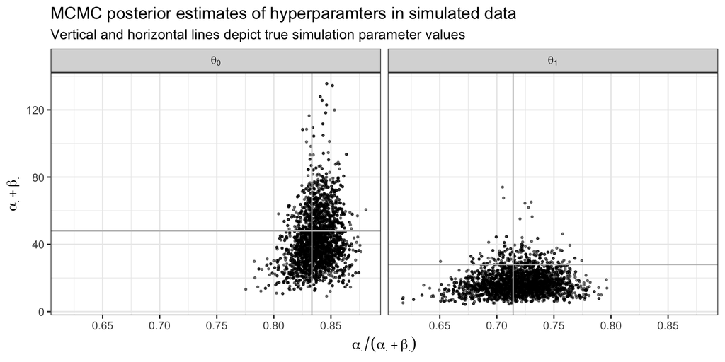

Note that Carpenter (2008, 22) stresses that “the lack of centering on the simulated value is not evidence of bias. Rather, it reflects the variance of the underlying sampling.”

#### Posterior coder ability estimates

Inspecting the marginal posterior densities of ability parameters by coder, we see model fares less well in recovering simulated ability values:

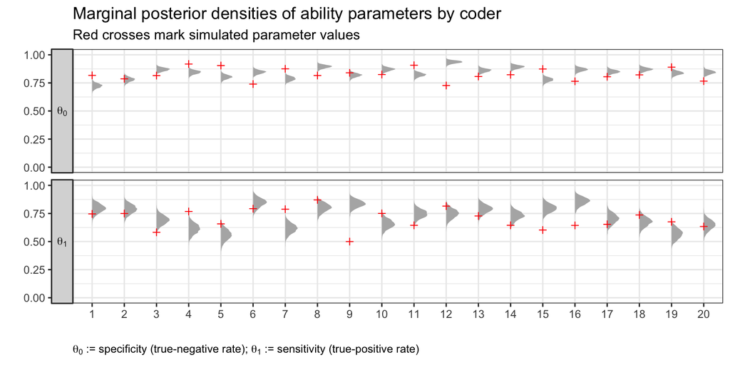

For many coders, the mass of marginal posterior densities does not cover the simulated parameter values. Importantly, this cannot have much to do with the pull of the prior, since if this were the case, posterior density masses should be systematically remove from true values, which is not the case.[^7]

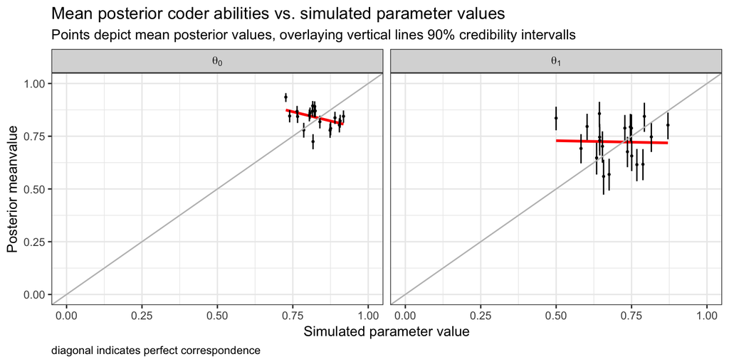

This result is sobering and stunning, since I basically chose the same simulation parameter values as Carpenter (2008 Subsection 3.2). Nevertheless, I cannot reproduce his Figure 9 (he demonstrates strong positive correlation between simulated and posterior mean values).

#### Posterior classifications

The model in its current implementation also performs poorly in recovering items true classes. Its accuracy in classifying items is only 0.682. Indeed, we quiety confidently missclassify a sizable number of items:

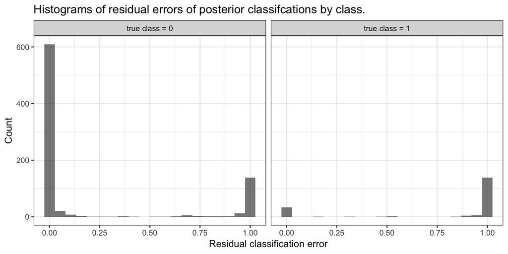

To generate this plot, I have computed classification error as the proportion of assginments to the positive class if true class is negative, and the proportion of assginments to the negative class if true class is positive. All items with residual error > .5 are misclassified. The group of items with residual error close to 1 is very confidently misclassified.

I also replicate Carpenter’s Figure 12, for which I computes residual ‘category’ (classification) error simply be substracting posterior mean class estimates from true class values (mind slaling of y-axis).

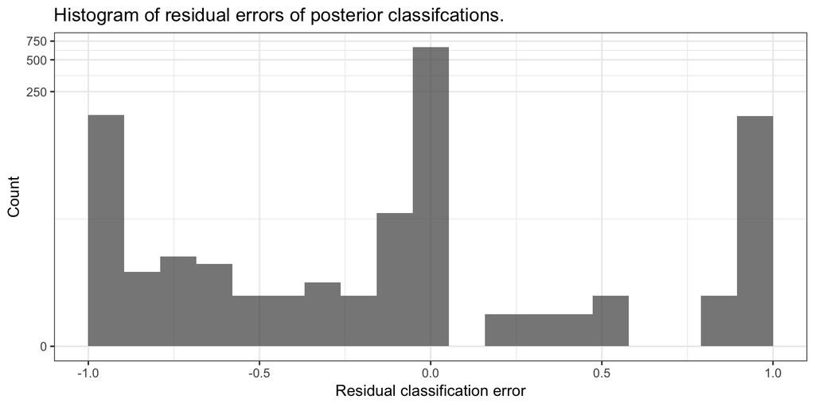

This underlines that when I fit the BBA model to the simulated data, it performs far worse than what Carpenter schows.

### Summary

The model does a good job to recover hyperparameter values, but performs relatively poorly in recovering coder abilities and items’ true classes. I don’t understand why I could not reproduce Carpenter’s results. A hunch is that because he constrained ability parameter estimates to be greate than .5 in order to avoid that chains converge on the revers parameter assignment (an approach he does not recommend in realistic settings), he artificially inflates the correlation between ability paramter estimates and true values.

## References

Carpenter, Bob. 2008. “Multilevel Bayesian Models of Categorical Data Annotation.” Unpublished manuscript. unpublished manuscript. http://citeseerx.ist.psu.edu/viewdoc/download?doi=10.1.1.174.1374&rep=rep1&type=pdf.